# 01PY_introduction

## Python Data Analysis 1

First moves in the book

### Intro and Help

One of the major components of the Jupyter project is the notebook, a type of interactive document for code, text (with or without markup), data visualizations, and other output. The Jupyter notebook interacts with kernels, which are implementations of the Jupyter interactive computing protocol in any number of programming languages. Python’s Jupyter kernel uses the IPython system for its underlying behavior.

On many platforms, Jupyter will automatically open up in your default web browser (unless you start it with --no-browser). Otherwise, you can navigate to the HTTP address printed when you started the notebook, here http://localhost:8888/.

```python
def add_numbers(a, b):
    """
    Add two numbers together

    Returns
    -------
    the_sum : type of arguments
    """
    return a + b
```

```python
# get information from the objects
add_numbers?
```

```
Signature: add_numbers(a, b)
Docstring:
Add two numbers together

Returns
-------
the_sum : type of arguments
File:      ~/Documents/GitHub/data_science/ncaa_2018/progPY/<ipython-input-3-0e543d60c645>
Type:      function
```

```python
# with double ? it is possible to have a quick look at the function in its functional form
add_numbers??
```

```
Signature: add_numbers(a, b)
Source:
def add_numbers(a, b):
    """
    Add two numbers together

    Returns
    -------
    the_sum : type of arguments
    """
    return a + b
File:      ~/Documents/GitHub/data_science/ncaa_2018/progPY/<ipython-input-3-0e543d60c645>
Type:      function
```

```python
import os
os.getcwd()
os.chdir('/Users/stefanopozzati/Documents/GitHub/data_science/python_data_analysis/progPY/')
```

### Magic commands

```python
%run PY_test_hello_world.py
```

```
hello world!
```

```python
# commands which starts with % are magic commands
%pwd #get wd
```

```
'/Users/stefanopozzati/Documents/GitHub/data_science/python_data_analysis/progPY'
```

```python
a = [1,3,2,4]
```

```python
%whos
```

```
Variable      Type        Data/Info
-----------------------------------
a             list        n=4
add_numbers   function    <function add_numbers at 0x103f0c0d0>
os            module      <module 'os' from '/usr/l<...>3.6/lib/python3.6/os.py'>
```

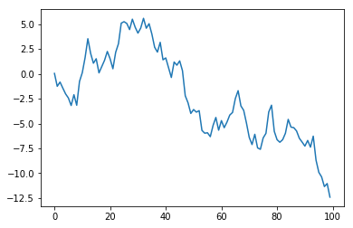

```python
import numpy as np
%matplotlib inline
import matplotlib.pyplot as plt
plt.plot(np.random.randn(100).cumsum())
```

Python use whitespace in order to structure the code rk = 4 spaces is the standard

```python
less = []
greater = []
a = np.array([1,2,3,4])
type(a)

for x in a:
    if x < 2:
        less.append(x)
    else:
        greater.append(x)
```

```python
%whos
```

```
Variable      Type        Data/Info
-----------------------------------
a             ndarray     4: 4 elems, type `int64`, 32 bytes
add_numbers   function    <function add_numbers at 0x103f0c0d0>
greater       list        n=3
less          list        n=1
np            module      <module 'numpy' from '/us<...>kages/numpy/__init__.py'>
os            module      <module 'os' from '/usr/l<...>3.6/lib/python3.6/os.py'>
plt           module      <module 'matplotlib.pyplo<...>es/matplotlib/pyplot.py'>
x             int64       4
```

La tipologia di dati e' importante specialmente all'interno di funzioni. Quindi diventa interessante poter controllare il type per assicurarsi la corretta esecuzione

```python
a = 5
isinstance(a, int)
```

```
True
```

### Null Values

None is the Python null value type. If a function does not explicitly return a value, it implicitly returns None

```python
def add_and_maybe_multiply(a, b, c=None):
    result = a + b

    if c is not None:
        result = result * c

    return result

add_and_maybe_multiply(1,2)

add_and_maybe_multiply(1,2, 5)
```

```
15
```

### Date

The built-in Python datetime module provides datetime, date, and time types.

```python
from datetime import datetime, date, time

dt = datetime(2011, 10, 29, 20, 30, 21)
```

```python
dt.minute
```

```
30
```

```python
dt.date()
```

```
datetime.date(2011, 10, 29)
```

```python
dt.time()
```

```
datetime.time(20, 30, 21)
```

```python
dt.strftime('%d/%m/%Y %H:%M')
```

```
'29/10/2011 20:30'
```

```python
datetime.strptime('20091031', '%Y%m%d')
```

```
datetime.datetime(2009, 10, 31, 0, 0)
```

```python
dt.replace(minute=0, second=0) # in case you need to aggregate
```

```
datetime.datetime(2011, 10, 29, 20, 0)
```

```python
dt2 = datetime(2011, 11, 15, 22, 30)
delta = dt2 - dt
type(delta)
```

```
datetime.timedelta
```

### Control Flow

An if statement can be optionally followed by one or more elif blocks and a catch-all else block if all of the conditions are False

```python
# ifelse
if x < 0:
    print("It's negative")
elif x == 0:
    print('Equal to zero')
elif 0 < x < 5:
    print('Positive but smaller than 5')
else:
    print('Positive and larger than or equal to 5')
```

```
Positive but smaller than 5
```

```python
# for loops
sequence = [1, 2, None, 4, None, 5]
total = 0
for value in sequence:
    if value is None:
        continue
    total += value
```

```python
# break for loop
sequence = [1, 2, 0, 4, 6, 5, 2, 1]
total_until_5 = 0
for value in sequence:
    if value == 5:
        break
    total_until_5 += value
```

```python
total_until_5
```

```
13
```

```python
# while loops
# A while loop specifies a condition and a block of code that is to be executed until the condition evaluates to False or
# the loop is explicitly ended with break
x = 256
total = 0
while x > 0:
    if total > 500:
        break
    total += x
    x = x // 2
```

```python
total
```

```
504
```